# Optimal Treatment Analysis

## Outcome Variable

**Outcome Variable:** ever_stunted

## Predictor Variables

**Intervention Variable:** brthmon

**Adjustment Set:**

unadjusted

## Stratifying Variables

The analysis was stratified on these variable(s):

- agecat
- studyid
- country

## Data Summary

| agecat | studyid | country | brthmon | ever_stunted | n_cell | n |
| --- | --- | --- | --- | --- | --- | --- |
| 0-24 months | ki0047075b-MAL-ED | BANGLADESH | 1 | 0 | 8 | 265 |
| 0-24 months | ki0047075b-MAL-ED | BANGLADESH | 1 | 1 | 13 | 265 |
| 0-24 months | ki0047075b-MAL-ED | BANGLADESH | 2 | 0 | 7 | 265 |
| 0-24 months | ki0047075b-MAL-ED | BANGLADESH | 2 | 1 | 18 | 265 |
| 0-24 months | ki0047075b-MAL-ED | BANGLADESH | 3 | 0 | 8 | 265 |
| 0-24 months | ki0047075b-MAL-ED | BANGLADESH | 3 | 1 | 17 | 265 |
| 0-24 months | ki0047075b-MAL-ED | BANGLADESH | 4 | 0 | 12 | 265 |
| 0-24 months | ki0047075b-MAL-ED | BANGLADESH | 4 | 1 | 10 | 265 |
| 0-24 months | ki0047075b-MAL-ED | BANGLADESH | 5 | 0 | 5 | 265 |
| 0-24 months | ki0047075b-MAL-ED | BANGLADESH | 5 | 1 | 17 | 265 |
| 0-24 months | ki0047075b-MAL-ED | BANGLADESH | 6 | 0 | 5 | 265 |
| 0-24 months | ki0047075b-MAL-ED | BANGLADESH | 6 | 1 | 6 | 265 |
| 0-24 months | ki0047075b-MAL-ED | BANGLADESH | 7 | 0 | 7 | 265 |
| 0-24 months | ki0047075b-MAL-ED | BANGLADESH | 7 | 1 | 13 | 265 |
| 0-24 months | ki0047075b-MAL-ED | BANGLADESH | 8 | 0 | 10 | 265 |
| 0-24 months | ki0047075b-MAL-ED | BANGLADESH | 8 | 1 | 16 | 265 |
| 0-24 months | ki0047075b-MAL-ED | BANGLADESH | 9 | 0 | 10 | 265 |
| 0-24 months | ki0047075b-MAL-ED | BANGLADESH | 9 | 1 | 13 | 265 |
| 0-24 months | ki0047075b-MAL-ED | BANGLADESH | 10 | 0 | 13 | 265 |
| 0-24 months | ki0047075b-MAL-ED | BANGLADESH | 10 | 1 | 12 | 265 |
| 0-24 months | ki0047075b-MAL-ED | BANGLADESH | 11 | 0 | 8 | 265 |
| 0-24 months | ki0047075b-MAL-ED | BANGLADESH | 11 | 1 | 9 | 265 |
| 0-24 months | ki0047075b-MAL-ED | BANGLADESH | 12 | 0 | 11 | 265 |
| 0-24 months | ki0047075b-MAL-ED | BANGLADESH | 12 | 1 | 17 | 265 |
| 0-24 months | ki0047075b-MAL-ED | BRAZIL | 1 | 0 | 12 | 233 |
| 0-24 months | ki0047075b-MAL-ED | BRAZIL | 1 | 1 | 3 | 233 |
| 0-24 months | ki0047075b-MAL-ED | BRAZIL | 2 | 0 | 18 | 233 |
| 0-24 months | ki0047075b-MAL-ED | BRAZIL | 2 | 1 | 7 | 233 |
| 0-24 months | ki0047075b-MAL-ED | BRAZIL | 3 | 0 | 16 | 233 |
| 0-24 months | ki0047075b-MAL-ED | BRAZIL | 3 | 1 | 4 | 233 |

[output cut: 2034 more lines]

The following strata were considered:

- agecat: 0-24 months, studyid: ki0047075b-MAL-ED, country: BANGLADESH
- agecat: 0-24 months, studyid: ki0047075b-MAL-ED, country: BRAZIL
- agecat: 0-24 months, studyid: ki0047075b-MAL-ED, country: INDIA
- agecat: 0-24 months, studyid: ki0047075b-MAL-ED, country: NEPAL
- agecat: 0-24 months, studyid: ki0047075b-MAL-ED, country: PERU
- agecat: 0-24 months, studyid: ki0047075b-MAL-ED, country: SOUTH AFRICA
- agecat: 0-24 months, studyid: ki0047075b-MAL-ED, country: TANZANIA, UNITED REPUBLIC OF
- agecat: 0-24 months, studyid: ki1000108-CMC-V-BCS-2002, country: INDIA
- agecat: 0-24 months, studyid: ki1000108-IRC, country: INDIA
- agecat: 0-24 months, studyid: ki1000109-EE, country: PAKISTAN
- agecat: 0-24 months, studyid: ki1000109-ResPak, country: PAKISTAN
- agecat: 0-24 months, studyid: ki1000304b-SAS-CompFeed, country: INDIA
- agecat: 0-24 months, studyid: ki1000304b-SAS-FoodSuppl, country: INDIA
- agecat: 0-24 months, studyid: ki1017093-NIH-Birth, country: BANGLADESH
- agecat: 0-24 months, studyid: ki1066203-TanzaniaChild2, country: TANZANIA, UNITED REPUBLIC OF
- agecat: 0-24 months, studyid: ki1101329-Keneba, country: GAMBIA
- agecat: 0-24 months, studyid: ki1112895-Guatemala BSC, country: GUATEMALA
- agecat: 0-24 months, studyid: ki1112895-iLiNS-Zinc, country: BURKINA FASO
- agecat: 0-24 months, studyid: ki1113344-GMS-Nepal, country: NEPAL
- agecat: 0-24 months, studyid: ki1114097-CMIN, country: BANGLADESH
- agecat: 0-24 months, studyid: ki1114097-CMIN, country: BRAZIL
- agecat: 0-24 months, studyid: ki1114097-CMIN, country: GUINEA-BISSAU
- agecat: 0-24 months, studyid: ki1114097-CMIN, country: PERU
- agecat: 0-24 months, studyid: ki1114097-CONTENT, country: PERU
- agecat: 0-24 months, studyid: ki1119695-PROBIT, country: BELARUS
- agecat: 0-24 months, studyid: ki1126311-ZVITAMBO, country: ZIMBABWE
- agecat: 0-24 months, studyid: ki1148112-LCNI-5, country: MALAWI
- agecat: 0-24 months, studyid: kiGH5241-JiVitA-3, country: BANGLADESH
- agecat: 0-24 months, studyid: kiGH5241-JiVitA-4, country: BANGLADESH
- agecat: 0-6 months, studyid: ki0047075b-MAL-ED, country: BANGLADESH
- agecat: 0-6 months, studyid: ki0047075b-MAL-ED, country: BRAZIL
- agecat: 0-6 months, studyid: ki0047075b-MAL-ED, country: INDIA
- agecat: 0-6 months, studyid: ki0047075b-MAL-ED, country: NEPAL
- agecat: 0-6 months, studyid: ki0047075b-MAL-ED, country: PERU
- agecat: 0-6 months, studyid: ki0047075b-MAL-ED, country: SOUTH AFRICA
- agecat: 0-6 months, studyid: ki0047075b-MAL-ED, country: TANZANIA, UNITED REPUBLIC OF
- agecat: 0-6 months, studyid: ki1000108-CMC-V-BCS-2002, country: INDIA
- agecat: 0-6 months, studyid: ki1000108-IRC, country: INDIA
- agecat: 0-6 months, studyid: ki1000109-EE, country: PAKISTAN
- agecat: 0-6 months, studyid: ki1000109-ResPak, country: PAKISTAN
- agecat: 0-6 months, studyid: ki1000304b-SAS-CompFeed, country: INDIA
- agecat: 0-6 months, studyid: ki1000304b-SAS-FoodSuppl, country: INDIA
- agecat: 0-6 months, studyid: ki1017093-NIH-Birth, country: BANGLADESH
- agecat: 0-6 months, studyid: ki1066203-TanzaniaChild2, country: TANZANIA, UNITED REPUBLIC OF
- agecat: 0-6 months, studyid: ki1101329-Keneba, country: GAMBIA
- agecat: 0-6 months, studyid: ki1112895-Guatemala BSC, country: GUATEMALA
- agecat: 0-6 months, studyid: ki1113344-GMS-Nepal, country: NEPAL
- agecat: 0-6 months, studyid: ki1114097-CMIN, country: BANGLADESH
- agecat: 0-6 months, studyid: ki1114097-CMIN, country: BRAZIL
- agecat: 0-6 months, studyid: ki1114097-CMIN, country: GUINEA-BISSAU
- agecat: 0-6 months, studyid: ki1114097-CMIN, country: PERU
- agecat: 0-6 months, studyid: ki1114097-CONTENT, country: PERU
- agecat: 0-6 months, studyid: ki1119695-PROBIT, country: BELARUS
- agecat: 0-6 months, studyid: ki1126311-ZVITAMBO, country: ZIMBABWE
- agecat: 0-6 months, studyid: ki1148112-LCNI-5, country: MALAWI
- agecat: 0-6 months, studyid: kiGH5241-JiVitA-3, country: BANGLADESH
- agecat: 0-6 months, studyid: kiGH5241-JiVitA-4, country: BANGLADESH
- agecat: 6-24 months, studyid: ki0047075b-MAL-ED, country: BANGLADESH
- agecat: 6-24 months, studyid: ki0047075b-MAL-ED, country: BRAZIL
- agecat: 6-24 months, studyid: ki0047075b-MAL-ED, country: INDIA
- agecat: 6-24 months, studyid: ki0047075b-MAL-ED, country: NEPAL
- agecat: 6-24 months, studyid: ki0047075b-MAL-ED, country: PERU
- agecat: 6-24 months, studyid: ki0047075b-MAL-ED, country: SOUTH AFRICA
- agecat: 6-24 months, studyid: ki0047075b-MAL-ED, country: TANZANIA, UNITED REPUBLIC OF
- agecat: 6-24 months, studyid: ki1000108-CMC-V-BCS-2002, country: INDIA
- agecat: 6-24 months, studyid: ki1000108-IRC, country: INDIA
- agecat: 6-24 months, studyid: ki1000109-EE, country: PAKISTAN
- agecat: 6-24 months, studyid: ki1000109-ResPak, country: PAKISTAN
- agecat: 6-24 months, studyid: ki1000304b-SAS-CompFeed, country: INDIA
- agecat: 6-24 months, studyid: ki1000304b-SAS-FoodSuppl, country: INDIA
- agecat: 6-24 months, studyid: ki1017093-NIH-Birth, country: BANGLADESH
- agecat: 6-24 months, studyid: ki1066203-TanzaniaChild2, country: TANZANIA, UNITED REPUBLIC OF
- agecat: 6-24 months, studyid: ki1101329-Keneba, country: GAMBIA
- agecat: 6-24 months, studyid: ki1112895-Guatemala BSC, country: GUATEMALA
- agecat: 6-24 months, studyid: ki1112895-iLiNS-Zinc, country: BURKINA FASO
- agecat: 6-24 months, studyid: ki1113344-GMS-Nepal, country: NEPAL
- agecat: 6-24 months, studyid: ki1114097-CMIN, country: BANGLADESH
- agecat: 6-24 months, studyid: ki1114097-CMIN, country: BRAZIL
- agecat: 6-24 months, studyid: ki1114097-CMIN, country: GUINEA-BISSAU
- agecat: 6-24 months, studyid: ki1114097-CMIN, country: PERU
- agecat: 6-24 months, studyid: ki1114097-CONTENT, country: PERU
- agecat: 6-24 months, studyid: ki1119695-PROBIT, country: BELARUS
- agecat: 6-24 months, studyid: ki1126311-ZVITAMBO, country: ZIMBABWE
- agecat: 6-24 months, studyid: ki1148112-LCNI-5, country: MALAWI
- agecat: 6-24 months, studyid: kiGH5241-JiVitA-3, country: BANGLADESH
- agecat: 6-24 months, studyid: kiGH5241-JiVitA-4, country: BANGLADESH

### Dropped Strata

Some strata were dropped due to rare outcomes:

- agecat: 0-24 months, studyid: ki0047075b-MAL-ED, country: BRAZIL
- agecat: 0-24 months, studyid: ki0047075b-MAL-ED, country: INDIA
- agecat: 0-24 months, studyid: ki0047075b-MAL-ED, country: NEPAL
- agecat: 0-24 months, studyid: ki0047075b-MAL-ED, country: SOUTH AFRICA
- agecat: 0-24 months, studyid: ki0047075b-MAL-ED, country: TANZANIA, UNITED REPUBLIC OF
- agecat: 0-24 months, studyid: ki1000108-CMC-V-BCS-2002, country: INDIA
- agecat: 0-24 months, studyid: ki1000108-IRC, country: INDIA
- agecat: 0-24 months, studyid: ki1000109-EE, country: PAKISTAN
- agecat: 0-24 months, studyid: ki1000109-ResPak, country: PAKISTAN
- agecat: 0-24 months, studyid: ki1000304b-SAS-FoodSuppl, country: INDIA
- agecat: 0-24 months, studyid: ki1112895-Guatemala BSC, country: GUATEMALA
- agecat: 0-24 months, studyid: ki1113344-GMS-Nepal, country: NEPAL
- agecat: 0-24 months, studyid: ki1114097-CMIN, country: BANGLADESH
- agecat: 0-24 months, studyid: ki1114097-CMIN, country: BRAZIL
- agecat: 0-24 months, studyid: ki1114097-CONTENT, country: PERU
- agecat: 0-24 months, studyid: kiGH5241-JiVitA-4, country: BANGLADESH
- agecat: 0-6 months, studyid: ki0047075b-MAL-ED, country: BANGLADESH
- agecat: 0-6 months, studyid: ki0047075b-MAL-ED, country: BRAZIL
- agecat: 0-6 months, studyid: ki0047075b-MAL-ED, country: INDIA
- agecat: 0-6 months, studyid: ki0047075b-MAL-ED, country: NEPAL
- agecat: 0-6 months, studyid: ki0047075b-MAL-ED, country: PERU
- agecat: 0-6 months, studyid: ki0047075b-MAL-ED, country: SOUTH AFRICA
- agecat: 0-6 months, studyid: ki0047075b-MAL-ED, country: TANZANIA, UNITED REPUBLIC OF
- agecat: 0-6 months, studyid: ki1000109-EE, country: PAKISTAN
- agecat: 0-6 months, studyid: ki1000109-ResPak, country: PAKISTAN
- agecat: 0-6 months, studyid: ki1000304b-SAS-FoodSuppl, country: INDIA
- agecat: 0-6 months, studyid: ki1112895-Guatemala BSC, country: GUATEMALA
- agecat: 0-6 months, studyid: ki1113344-GMS-Nepal, country: NEPAL
- agecat: 0-6 months, studyid: ki1114097-CMIN, country: BANGLADESH
- agecat: 0-6 months, studyid: ki1114097-CMIN, country: BRAZIL
- agecat: 0-6 months, studyid: ki1114097-CMIN, country: GUINEA-BISSAU
- agecat: 0-6 months, studyid: ki1114097-CMIN, country: PERU
- agecat: 0-6 months, studyid: ki1114097-CONTENT, country: PERU
- agecat: 0-6 months, studyid: ki1148112-LCNI-5, country: MALAWI
- agecat: 0-6 months, studyid: kiGH5241-JiVitA-4, country: BANGLADESH
- agecat: 6-24 months, studyid: ki0047075b-MAL-ED, country: BANGLADESH
- agecat: 6-24 months, studyid: ki0047075b-MAL-ED, country: BRAZIL
- agecat: 6-24 months, studyid: ki0047075b-MAL-ED, country: INDIA
- agecat: 6-24 months, studyid: ki0047075b-MAL-ED, country: NEPAL
- agecat: 6-24 months, studyid: ki0047075b-MAL-ED, country: PERU
- agecat: 6-24 months, studyid: ki0047075b-MAL-ED, country: SOUTH AFRICA
- agecat: 6-24 months, studyid: ki0047075b-MAL-ED, country: TANZANIA, UNITED REPUBLIC OF
- agecat: 6-24 months, studyid: ki1000108-CMC-V-BCS-2002, country: INDIA
- agecat: 6-24 months, studyid: ki1000108-IRC, country: INDIA
- agecat: 6-24 months, studyid: ki1000109-EE, country: PAKISTAN
- agecat: 6-24 months, studyid: ki1000109-ResPak, country: PAKISTAN
- agecat: 6-24 months, studyid: ki1000304b-SAS-FoodSuppl, country: INDIA
- agecat: 6-24 months, studyid: ki1112895-Guatemala BSC, country: GUATEMALA
- agecat: 6-24 months, studyid: ki1113344-GMS-Nepal, country: NEPAL
- agecat: 6-24 months, studyid: ki1114097-CMIN, country: BANGLADESH
- agecat: 6-24 months, studyid: ki1114097-CMIN, country: BRAZIL
- agecat: 6-24 months, studyid: ki1114097-CONTENT, country: PERU
- agecat: 6-24 months, studyid: kiGH5241-JiVitA-4, country: BANGLADESH

## Methods Detail

We’re interested in the causal parameters $E[Y_a]$ for all values of $a \in \mathcal{A}$. These parameters represent the mean outcome if, possibly contrary to fact, we intervened to set all units to have $A=a$. Under the randomization and positivity assumptions, these are identified by the statistical parameters $\psi_a=E_W[E_{Y|A,W}(Y|A=a,W)]$. In addition, we’re interested in the mean of $Y$, $E[Y]$ under no intervention (the observed mean). We will estimate these parameters by using SuperLearner to fit the relevant likelihood factors – $E_{Y|A,W}(Y|A=a,W)$ and $p(A=a|W)$, and then updating our likelihood fit using a joint TMLE.

For unadjusted analyses ($W=\{\}$), initial likelihoods were estimated using Lrnr_glm to estimate the simple $E(Y|A)$ and Lrnr_mean to estimate $p(A)$. For adjusted analyses, a small library containing Lrnr_glmnet, Lrnr_xgboost, and Lrnr_mean was used.

Having estimated these parameters, we will then use the delta method to estimate relative risks and attributable risks relative to a prespecified baseline level of $A$.

# Results Detail

## Results Plots

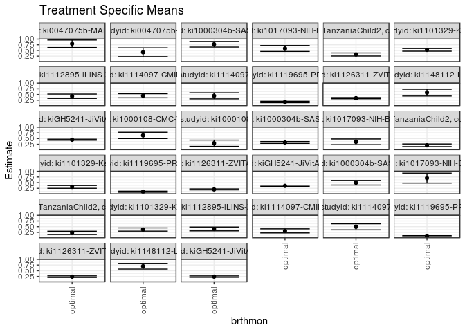

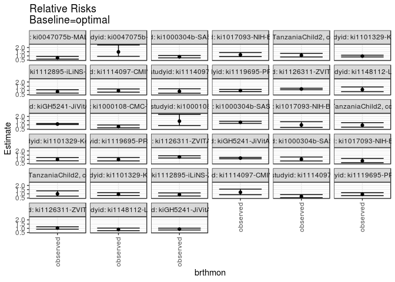

## Results Table

### Parameter: TSM

| agecat | studyid | country | intervention_level | baseline_level | estimate | ci_lower | ci_upper |
| --- | --- | --- | --- | --- | --- | --- | --- |
| 0-24 months | ki0047075b-MAL-ED | BANGLADESH | optimal | NA | 0.7951722 | 0.6300387 | 0.9603057 |
| 0-24 months | ki0047075b-MAL-ED | PERU | optimal | NA | 0.4207353 | 0.2264235 | 0.6150472 |
| 0-24 months | ki1000304b-SAS-CompFeed | INDIA | optimal | NA | 0.7722780 | 0.6490253 | 0.8955306 |
| 0-24 months | ki1017093-NIH-Birth | BANGLADESH | optimal | NA | 0.5867013 | 0.4562555 | 0.7171472 |
| 0-24 months | ki1066203-TanzaniaChild2 | TANZANIA, UNITED REPUBLIC OF | optimal | NA | 0.3238506 | 0.2559125 | 0.3917886 |
| 0-24 months | ki1101329-Keneba | GAMBIA | optimal | NA | 0.5256055 | 0.4673380 | 0.5838731 |
| 0-24 months | ki1112895-iLiNS-Zinc | BURKINA FASO | optimal | NA | 0.4243760 | 0.3307249 | 0.5180271 |
| 0-24 months | ki1114097-CMIN | GUINEA-BISSAU | optimal | NA | 0.4454580 | 0.3564232 | 0.5344929 |
| 0-24 months | ki1114097-CMIN | PERU | optimal | NA | 0.4425842 | 0.3092767 | 0.5758918 |
| 0-24 months | ki1119695-PROBIT | BELARUS | optimal | NA | 0.1713508 | 0.1396902 | 0.2030114 |
| 0-24 months | ki1126311-ZVITAMBO | ZIMBABWE | optimal | NA | 0.3398631 | 0.3141382 | 0.3655881 |
| 0-24 months | ki1148112-LCNI-5 | MALAWI | optimal | NA | 0.5823208 | 0.4326715 | 0.7319701 |
| 0-24 months | kiGH5241-JiVitA-3 | BANGLADESH | optimal | NA | 0.4490238 | 0.4253959 | 0.4726517 |
| 0-6 months | ki1000108-CMC-V-BCS-2002 | INDIA | optimal | NA | 0.6389134 | 0.5018955 | 0.7759314 |
| 0-6 months | ki1000108-IRC | INDIA | optimal | NA | 0.2944513 | 0.1575200 | 0.4313825 |
| 0-6 months | ki1000304b-SAS-CompFeed | INDIA | optimal | NA | 0.3277474 | 0.2872545 | 0.3682404 |
| 0-6 months | ki1017093-NIH-Birth | BANGLADESH | optimal | NA | 0.3557166 | 0.2302871 | 0.4811460 |
| 0-6 months | ki1066203-TanzaniaChild2 | TANZANIA, UNITED REPUBLIC OF | optimal | NA | 0.2035791 | 0.1451021 | 0.2620562 |
| 0-6 months | ki1101329-Keneba | GAMBIA | optimal | NA | 0.3124446 | 0.2498107 | 0.3750786 |
| 0-6 months | ki1119695-PROBIT | BELARUS | optimal | NA | 0.0998482 | 0.0758778 | 0.1238186 |
| 0-6 months | ki1126311-ZVITAMBO | ZIMBABWE | optimal | NA | 0.2012326 | 0.1794759 | 0.2229893 |
| 0-6 months | kiGH5241-JiVitA-3 | BANGLADESH | optimal | NA | 0.3572045 | 0.3295940 | 0.3848150 |
| 6-24 months | ki1000304b-SAS-CompFeed | INDIA | optimal | NA | 0.4953790 | 0.3944323 | 0.5963257 |
| 6-24 months | ki1017093-NIH-Birth | BANGLADESH | optimal | NA | 0.6991503 | 0.4798093 | 0.9184914 |
| 6-24 months | ki1066203-TanzaniaChild2 | TANZANIA, UNITED REPUBLIC OF | optimal | NA | 0.2265978 | 0.1536238 | 0.2995718 |
| 6-24 months | ki1101329-Keneba | GAMBIA | optimal | NA | 0.3744705 | 0.3034520 | 0.4454889 |
| 6-24 months | ki1112895-iLiNS-Zinc | BURKINA FASO | optimal | NA | 0.3992359 | 0.3148823 | 0.4835894 |
| 6-24 months | ki1114097-CMIN | GUINEA-BISSAU | optimal | NA | 0.3140681 | 0.2239638 | 0.4041724 |
| 6-24 months | ki1114097-CMIN | PERU | optimal | NA | 0.4929766 | 0.3594542 | 0.6264989 |
| 6-24 months | ki1119695-PROBIT | BELARUS | optimal | NA | 0.0813047 | 0.0568978 | 0.1057115 |
| 6-24 months | ki1126311-ZVITAMBO | ZIMBABWE | optimal | NA | 0.2394997 | 0.2054281 | 0.2735713 |
| 6-24 months | ki1148112-LCNI-5 | MALAWI | optimal | NA | 0.6972925 | 0.5726383 | 0.8219466 |
| 6-24 months | kiGH5241-JiVitA-3 | BANGLADESH | optimal | NA | 0.2413781 | 0.2111004 | 0.2716559 |

### Parameter: E(Y)

| agecat | studyid | country | intervention_level | baseline_level | estimate | ci_lower | ci_upper |
| --- | --- | --- | --- | --- | --- | --- | --- |
| 0-24 months | ki0047075b-MAL-ED | BANGLADESH | observed | NA | 0.6075472 | 0.5486452 | 0.6664491 |
| 0-24 months | ki0047075b-MAL-ED | PERU | observed | NA | 0.6204620 | 0.5657315 | 0.6751926 |
| 0-24 months | ki1000304b-SAS-CompFeed | INDIA | observed | NA | 0.6914547 | 0.6510509 | 0.7318584 |
| 0-24 months | ki1017093-NIH-Birth | BANGLADESH | observed | NA | 0.6645469 | 0.6276196 | 0.7014742 |
| 0-24 months | ki1066203-TanzaniaChild2 | TANZANIA, UNITED REPUBLIC OF | observed | NA | 0.3459933 | 0.3269422 | 0.3650444 |
| 0-24 months | ki1101329-Keneba | GAMBIA | observed | NA | 0.5125214 | 0.4943731 | 0.5306698 |
| 0-24 months | ki1112895-iLiNS-Zinc | BURKINA FASO | observed | NA | 0.3623277 | 0.3130786 | 0.4115769 |
| 0-24 months | ki1114097-CMIN | GUINEA-BISSAU | observed | NA | 0.4286662 | 0.4036720 | 0.4536605 |
| 0-24 months | ki1114097-CMIN | PERU | observed | NA | 0.3928956 | 0.3614728 | 0.4243183 |
| 0-24 months | ki1119695-PROBIT | BELARUS | observed | NA | 0.1674854 | 0.1488048 | 0.1861659 |
| 0-24 months | ki1126311-ZVITAMBO | ZIMBABWE | observed | NA | 0.3966461 | 0.3885633 | 0.4047288 |
| 0-24 months | ki1148112-LCNI-5 | MALAWI | observed | NA | 0.6369048 | 0.6043650 | 0.6694445 |
| 0-24 months | kiGH5241-JiVitA-3 | BANGLADESH | observed | NA | 0.4937950 | 0.4859633 | 0.5016266 |
| 0-6 months | ki1000108-CMC-V-BCS-2002 | INDIA | observed | NA | 0.5108696 | 0.4597270 | 0.5620121 |
| 0-6 months | ki1000108-IRC | INDIA | observed | NA | 0.4243902 | 0.3764905 | 0.4722900 |
| 0-6 months | ki1000304b-SAS-CompFeed | INDIA | observed | NA | 0.4254902 | 0.3977202 | 0.4532601 |
| 0-6 months | ki1017093-NIH-Birth | BANGLADESH | observed | NA | 0.3497615 | 0.3124631 | 0.3870600 |
| 0-6 months | ki1066203-TanzaniaChild2 | TANZANIA, UNITED REPUBLIC OF | observed | NA | 0.1949082 | 0.1790434 | 0.2107729 |
| 0-6 months | ki1101329-Keneba | GAMBIA | observed | NA | 0.3123732 | 0.2940736 | 0.3306728 |
| 0-6 months | ki1119695-PROBIT | BELARUS | observed | NA | 0.0995087 | 0.0864641 | 0.1125533 |
| 0-6 months | ki1126311-ZVITAMBO | ZIMBABWE | observed | NA | 0.2579888 | 0.2507541 | 0.2652234 |
| 0-6 months | kiGH5241-JiVitA-3 | BANGLADESH | observed | NA | 0.4107840 | 0.4033446 | 0.4182233 |
| 6-24 months | ki1000304b-SAS-CompFeed | INDIA | observed | NA | 0.5030750 | 0.4588491 | 0.5473009 |
| 6-24 months | ki1017093-NIH-Birth | BANGLADESH | observed | NA | 0.5739130 | 0.5216565 | 0.6261696 |
| 6-24 months | ki1066203-TanzaniaChild2 | TANZANIA, UNITED REPUBLIC OF | observed | NA | 0.2259675 | 0.2054816 | 0.2464534 |
| 6-24 months | ki1101329-Keneba | GAMBIA | observed | NA | 0.3589489 | 0.3380095 | 0.3798884 |
| 6-24 months | ki1112895-iLiNS-Zinc | BURKINA FASO | observed | NA | 0.3623277 | 0.3130786 | 0.4115769 |
| 6-24 months | ki1114097-CMIN | GUINEA-BISSAU | observed | NA | 0.3714710 | 0.3456477 | 0.3972943 |
| 6-24 months | ki1114097-CMIN | PERU | observed | NA | 0.3450439 | 0.3120195 | 0.3780683 |
| 6-24 months | ki1119695-PROBIT | BELARUS | observed | NA | 0.0768510 | 0.0628857 | 0.0908164 |
| 6-24 months | ki1126311-ZVITAMBO | ZIMBABWE | observed | NA | 0.2459470 | 0.2364841 | 0.2554098 |
| 6-24 months | ki1148112-LCNI-5 | MALAWI | observed | NA | 0.6000000 | 0.5644377 | 0.6355623 |
| 6-24 months | kiGH5241-JiVitA-3 | BANGLADESH | observed | NA | 0.2173665 | 0.2079947 | 0.2267384 |

### Parameter: RR

| agecat | studyid | country | intervention_level | baseline_level | estimate | ci_lower | ci_upper |
| --- | --- | --- | --- | --- | --- | --- | --- |
| 0-24 months | ki0047075b-MAL-ED | BANGLADESH | observed | optimal | 0.7640448 | 0.6202284 | 0.9412087 |
| 0-24 months | ki0047075b-MAL-ED | PERU | observed | optimal | 1.4747087 | 0.9465190 | 2.2976461 |
| 0-24 months | ki1000304b-SAS-CompFeed | INDIA | observed | optimal | 0.8953443 | 0.7652944 | 1.0474942 |
| 0-24 months | ki1017093-NIH-Birth | BANGLADESH | observed | optimal | 1.1326835 | 0.9170825 | 1.3989711 |
| 0-24 months | ki1066203-TanzaniaChild2 | TANZANIA, UNITED REPUBLIC OF | observed | optimal | 1.0683734 | 0.8730560 | 1.3073866 |
| 0-24 months | ki1101329-Keneba | GAMBIA | observed | optimal | 0.9751067 | 0.8773707 | 1.0837301 |
| 0-24 months | ki1112895-iLiNS-Zinc | BURKINA FASO | observed | optimal | 0.8537893 | 0.6760352 | 1.0782815 |
| 0-24 months | ki1114097-CMIN | GUINEA-BISSAU | observed | optimal | 0.9623044 | 0.7943764 | 1.1657316 |
| 0-24 months | ki1114097-CMIN | PERU | observed | optimal | 0.8877306 | 0.6633563 | 1.1879976 |
| 0-24 months | ki1119695-PROBIT | BELARUS | observed | optimal | 0.9774413 | 0.8594023 | 1.1116930 |
| 0-24 months | ki1126311-ZVITAMBO | ZIMBABWE | observed | optimal | 1.1670759 | 1.0856205 | 1.2546430 |
| 0-24 months | ki1148112-LCNI-5 | MALAWI | observed | optimal | 1.0937353 | 0.8516736 | 1.4045954 |
| 0-24 months | kiGH5241-JiVitA-3 | BANGLADESH | observed | optimal | 1.0997079 | 1.0472062 | 1.1548418 |
| 0-6 months | ki1000108-CMC-V-BCS-2002 | INDIA | observed | optimal | 0.7995912 | 0.6472258 | 0.9878254 |
| 0-6 months | ki1000108-IRC | INDIA | observed | optimal | 1.4412919 | 0.9243263 | 2.2473909 |
| 0-6 months | ki1000304b-SAS-CompFeed | INDIA | observed | optimal | 1.2982258 | 1.1808652 | 1.4272503 |
| 0-6 months | ki1017093-NIH-Birth | BANGLADESH | observed | optimal | 0.9832590 | 0.7023392 | 1.3765404 |
| 0-6 months | ki1066203-TanzaniaChild2 | TANZANIA, UNITED REPUBLIC OF | observed | optimal | 0.9574075 | 0.7251818 | 1.2639991 |
| 0-6 months | ki1101329-Keneba | GAMBIA | observed | optimal | 0.9997715 | 0.8262670 | 1.2097094 |
| 0-6 months | ki1119695-PROBIT | BELARUS | observed | optimal | 0.9965996 | 0.8159684 | 1.2172172 |
| 0-6 months | ki1126311-ZVITAMBO | ZIMBABWE | observed | optimal | 1.2820426 | 1.1556028 | 1.4223167 |
| 0-6 months | kiGH5241-JiVitA-3 | BANGLADESH | observed | optimal | 1.1499965 | 1.0670027 | 1.2394458 |
| 6-24 months | ki1000304b-SAS-CompFeed | INDIA | observed | optimal | 1.0155357 | 0.8088128 | 1.2750945 |
| 6-24 months | ki1017093-NIH-Birth | BANGLADESH | observed | optimal | 0.8208722 | 0.6070264 | 1.1100523 |
| 6-24 months | ki1066203-TanzaniaChild2 | TANZANIA, UNITED REPUBLIC OF | observed | optimal | 0.9972185 | 0.7332511 | 1.3562130 |
| 6-24 months | ki1101329-Keneba | GAMBIA | observed | optimal | 0.9585507 | 0.8008865 | 1.1472531 |
| 6-24 months | ki1112895-iLiNS-Zinc | BURKINA FASO | observed | optimal | 0.9075530 | 0.7437236 | 1.1074713 |
| 6-24 months | ki1114097-CMIN | GUINEA-BISSAU | observed | optimal | 1.1827723 | 0.8971026 | 1.5594094 |
| 6-24 months | ki1114097-CMIN | PERU | observed | optimal | 0.6999195 | 0.5396642 | 0.9077632 |
| 6-24 months | ki1119695-PROBIT | BELARUS | observed | optimal | 0.9452231 | 0.7847837 | 1.1384625 |
| 6-24 months | ki1126311-ZVITAMBO | ZIMBABWE | observed | optimal | 1.0269197 | 0.8955365 | 1.1775780 |
| 6-24 months | ki1148112-LCNI-5 | MALAWI | observed | optimal | 0.8604711 | 0.7222706 | 1.0251151 |
| 6-24 months | kiGH5241-JiVitA-3 | BANGLADESH | observed | optimal | 0.9005228 | 0.7988476 | 1.0151389 |

### Parameter: PAR

| agecat | studyid | country | intervention_level | baseline_level | estimate | ci_lower | ci_upper |
| --- | --- | --- | --- | --- | --- | --- | --- |
| 0-24 months | ki0047075b-MAL-ED | BANGLADESH | optimal | NA | -0.1876250 | -0.3500204 | -0.0252297 |
| 0-24 months | ki0047075b-MAL-ED | PERU | optimal | NA | 0.1997267 | 0.0143360 | 0.3851175 |
| 0-24 months | ki1000304b-SAS-CompFeed | INDIA | optimal | NA | -0.0808233 | -0.2014580 | 0.0398114 |
| 0-24 months | ki1017093-NIH-Birth | BANGLADESH | optimal | NA | 0.0778456 | -0.0457852 | 0.2014763 |
| 0-24 months | ki1066203-TanzaniaChild2 | TANZANIA, UNITED REPUBLIC OF | optimal | NA | 0.0221428 | -0.0432399 | 0.0875254 |
| 0-24 months | ki1101329-Keneba | GAMBIA | optimal | NA | -0.0130841 | -0.0685917 | 0.0424235 |
| 0-24 months | ki1112895-iLiNS-Zinc | BURKINA FASO | optimal | NA | -0.0620483 | -0.1582052 | 0.0341086 |
| 0-24 months | ki1114097-CMIN | GUINEA-BISSAU | optimal | NA | -0.0167918 | -0.1022144 | 0.0686308 |
| 0-24 months | ki1114097-CMIN | PERU | optimal | NA | -0.0496887 | -0.1786516 | 0.0792743 |
| 0-24 months | ki1119695-PROBIT | BELARUS | optimal | NA | -0.0038655 | -0.0259997 | 0.0182688 |
| 0-24 months | ki1126311-ZVITAMBO | ZIMBABWE | optimal | NA | 0.0567829 | 0.0321979 | 0.0813679 |
| 0-24 months | ki1148112-LCNI-5 | MALAWI | optimal | NA | 0.0545840 | -0.0910171 | 0.2001851 |
| 0-24 months | kiGH5241-JiVitA-3 | BANGLADESH | optimal | NA | 0.0447712 | 0.0228510 | 0.0666914 |
| 0-6 months | ki1000108-CMC-V-BCS-2002 | INDIA | optimal | NA | -0.1280439 | -0.2610646 | 0.0049768 |
| 0-6 months | ki1000108-IRC | INDIA | optimal | NA | 0.1299390 | -0.0007832 | 0.2606612 |
| 0-6 months | ki1000304b-SAS-CompFeed | INDIA | optimal | NA | 0.0977427 | 0.0670811 | 0.1284044 |
| 0-6 months | ki1017093-NIH-Birth | BANGLADESH | optimal | NA | -0.0059551 | -0.1256376 | 0.1137275 |
| 0-6 months | ki1066203-TanzaniaChild2 | TANZANIA, UNITED REPUBLIC OF | optimal | NA | -0.0086709 | -0.0652108 | 0.0478689 |
| 0-6 months | ki1101329-Keneba | GAMBIA | optimal | NA | -0.0000714 | -0.0596261 | 0.0594833 |
| 0-6 months | ki1119695-PROBIT | BELARUS | optimal | NA | -0.0003395 | -0.0203069 | 0.0196279 |
| 0-6 months | ki1126311-ZVITAMBO | ZIMBABWE | optimal | NA | 0.0567562 | 0.0358344 | 0.0776779 |
| 0-6 months | kiGH5241-JiVitA-3 | BANGLADESH | optimal | NA | 0.0535794 | 0.0268181 | 0.0803408 |
| 6-24 months | ki1000304b-SAS-CompFeed | INDIA | optimal | NA | 0.0076961 | -0.1053602 | 0.1207523 |
| 6-24 months | ki1017093-NIH-Birth | BANGLADESH | optimal | NA | -0.1252373 | -0.3363489 | 0.0858743 |
| 6-24 months | ki1066203-TanzaniaChild2 | TANZANIA, UNITED REPUBLIC OF | optimal | NA | -0.0006303 | -0.0703060 | 0.0690454 |
| 6-24 months | ki1101329-Keneba | GAMBIA | optimal | NA | -0.0155215 | -0.0828329 | 0.0517898 |
| 6-24 months | ki1112895-iLiNS-Zinc | BURKINA FASO | optimal | NA | -0.0369081 | -0.1152915 | 0.0414752 |
| 6-24 months | ki1114097-CMIN | GUINEA-BISSAU | optimal | NA | 0.0574029 | -0.0294023 | 0.1442082 |
| 6-24 months | ki1114097-CMIN | PERU | optimal | NA | -0.1479326 | -0.2759271 | -0.0199381 |
| 6-24 months | ki1119695-PROBIT | BELARUS | optimal | NA | -0.0044536 | -0.0198655 | 0.0109583 |
| 6-24 months | ki1126311-ZVITAMBO | ZIMBABWE | optimal | NA | 0.0064473 | -0.0263398 | 0.0392344 |
| 6-24 months | ki1148112-LCNI-5 | MALAWI | optimal | NA | -0.0972925 | -0.2188963 | 0.0243114 |
| 6-24 months | kiGH5241-JiVitA-3 | BANGLADESH | optimal | NA | -0.0240116 | -0.0529006 | 0.0048774 |

### Parameter: PAF

| agecat | studyid | country | intervention_level | baseline_level | estimate | ci_lower | ci_upper |
| --- | --- | --- | --- | --- | --- | --- | --- |
| 0-24 months | ki0047075b-MAL-ED | BANGLADESH | optimal | NA | -0.3088238 | -0.6123093 | -0.0624636 |
| 0-24 months | ki0047075b-MAL-ED | PERU | optimal | NA | 0.3219000 | -0.0565028 | 0.5647720 |
| 0-24 months | ki1000304b-SAS-CompFeed | INDIA | optimal | NA | -0.1168888 | -0.3066867 | 0.0453408 |
| 0-24 months | ki1017093-NIH-Birth | BANGLADESH | optimal | NA | 0.1171408 | -0.0904145 | 0.2851890 |
| 0-24 months | ki1066203-TanzaniaChild2 | TANZANIA, UNITED REPUBLIC OF | optimal | NA | 0.0639977 | -0.1454019 | 0.2351153 |
| 0-24 months | ki1101329-Keneba | GAMBIA | optimal | NA | -0.0255288 | -0.1397691 | 0.0772611 |
| 0-24 months | ki1112895-iLiNS-Zinc | BURKINA FASO | optimal | NA | -0.1712491 | -0.4792130 | 0.0725984 |
| 0-24 months | ki1114097-CMIN | GUINEA-BISSAU | optimal | NA | -0.0391722 | -0.2588490 | 0.1421696 |
| 0-24 months | ki1114097-CMIN | PERU | optimal | NA | -0.1264678 | -0.5074855 | 0.1582474 |
| 0-24 months | ki1119695-PROBIT | BELARUS | optimal | NA | -0.0230793 | -0.1635994 | 0.1004711 |
| 0-24 months | ki1126311-ZVITAMBO | ZIMBABWE | optimal | NA | 0.1431577 | 0.0788678 | 0.2029605 |
| 0-24 months | ki1148112-LCNI-5 | MALAWI | optimal | NA | 0.0857020 | -0.1741588 | 0.2880512 |
| 0-24 months | kiGH5241-JiVitA-3 | BANGLADESH | optimal | NA | 0.0906676 | 0.0450782 | 0.1340805 |
| 0-6 months | ki1000108-CMC-V-BCS-2002 | INDIA | optimal | NA | -0.2506391 | -0.5450558 | -0.0123247 |
| 0-6 months | ki1000108-IRC | INDIA | optimal | NA | 0.3061780 | -0.0818691 | 0.5550396 |
| 0-6 months | ki1000304b-SAS-CompFeed | INDIA | optimal | NA | 0.2297180 | 0.1531633 | 0.2993520 |
| 0-6 months | ki1017093-NIH-Birth | BANGLADESH | optimal | NA | -0.0170260 | -0.4238135 | 0.2735411 |
| 0-6 months | ki1066203-TanzaniaChild2 | TANZANIA, UNITED REPUBLIC OF | optimal | NA | -0.0444873 | -0.3789645 | 0.2088602 |
| 0-6 months | ki1101329-Keneba | GAMBIA | optimal | NA | -0.0002286 | -0.2102625 | 0.1733552 |
| 0-6 months | ki1119695-PROBIT | BELARUS | optimal | NA | -0.0034120 | -0.2255376 | 0.1784539 |
| 0-6 months | ki1126311-ZVITAMBO | ZIMBABWE | optimal | NA | 0.2199947 | 0.1346508 | 0.2969217 |
| 0-6 months | kiGH5241-JiVitA-3 | BANGLADESH | optimal | NA | 0.1304321 | 0.0627952 | 0.1931878 |
| 6-24 months | ki1000304b-SAS-CompFeed | INDIA | optimal | NA | 0.0152980 | -0.2363800 | 0.2157444 |
| 6-24 months | ki1017093-NIH-Birth | BANGLADESH | optimal | NA | -0.2182165 | -0.6473748 | 0.0991416 |
| 6-24 months | ki1066203-TanzaniaChild2 | TANZANIA, UNITED REPUBLIC OF | optimal | NA | -0.0027893 | -0.3637893 | 0.2626527 |
| 6-24 months | ki1101329-Keneba | GAMBIA | optimal | NA | -0.0432416 | -0.2486164 | 0.1283528 |
| 6-24 months | ki1112895-iLiNS-Zinc | BURKINA FASO | optimal | NA | -0.1018640 | -0.3445855 | 0.0970420 |
| 6-24 months | ki1114097-CMIN | GUINEA-BISSAU | optimal | NA | 0.1545287 | -0.1146997 | 0.3587316 |
| 6-24 months | ki1114097-CMIN | PERU | optimal | NA | -0.4287357 | -0.8530040 | -0.1016089 |
| 6-24 months | ki1119695-PROBIT | BELARUS | optimal | NA | -0.0579513 | -0.2742365 | 0.1216223 |
| 6-24 months | ki1126311-ZVITAMBO | ZIMBABWE | optimal | NA | 0.0262140 | -0.1166491 | 0.1507994 |
| 6-24 months | ki1148112-LCNI-5 | MALAWI | optimal | NA | -0.1621541 | -0.3845226 | 0.0244997 |
| 6-24 months | kiGH5241-JiVitA-3 | BANGLADESH | optimal | NA | -0.1104660 | -0.2518032 | 0.0149132 |